# Bayside census analysis

Working note

Dr James Reynolds

2024-06-14

# Introduction

The Public Transport Research Group (PTRG) is reviewing census data for 2011, 2016 and 2021 for Greater Melbourne and the City of Bayside. Journey to work travel, mode and total cars per person are the particular areas of interest.

This working note details the analysis and results.

# Methodology

Australian Bureau of Statistics (ABS) census data was obtained using the TableBuilder platform. Details are as follows

## Population and population over 18

Population of driving age was extracted from the census results that are enumerated by place of usual residence. Data was loaded and cleaned for 2011, 2016 and 2021.

## Cars per dwelling

The number of cars is enumerated in the census for each dwelling. Data was loaded and cleaned for 2011, 2016 and 2021.

See https://www.abs.gov.au/census/guide-census-data/census-dictionary/2021/variables-topic/transport/number-motor-vehicles-vehd

# Results

## Population and population 18 and over

The following tables and figures show the population that is 18 years and older and the total populations in both the City of Bayside and the rest of Greater Melbourne.

Total population 18 and older

| Year | Bayside | Rest of Greater Melbourne | Total |
| --- | --- | --- | --- |
| 2011 | 2.3% (70,234) | 97.7% (3,042,426) | 100.0% (3,112,660) |
| 2016 | 2.1% (74,771) | 97.9% (3,437,742) | 100.0% (3,512,513) |
| 2021 | 2.1% (79,294) | 97.9% (3,782,478) | 100.0% (3,861,772) |

Bayside makes up ~2% of the population of Greater Melbourne. Almost 10k (+10%) more people in 2021 than in 2011, but less growth than Greater Melbourne as a whole (+23%).

Total population

| Year | Bayside | Rest of Greater Melbourne | Total |
| --- | --- | --- | --- |
| 2011 | 2.3% (91,813) | 97.7% (3,908,168) | 100.0% (3,999,981) |
| 2016 | 2.2% (97,092) | 97.8% (4,388,118) | 100.0% (4,485,210) |
| 2021 | 2.1% (101,306) | 97.9% (4,816,444) | 100.0% (4,917,750) |

A little over 9k (+13%) more people in Bayside are old enough to drive alone (Ps) in 2021 than in 2011. Greater Melbourne up by 24%.

Population share: younger than 18 compared to 18 and over

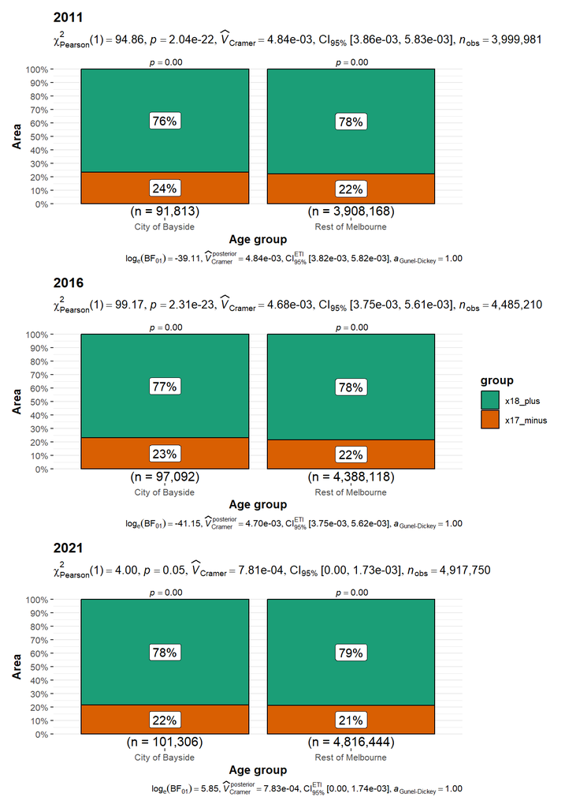

City of Bayside and Rest of Greater Melbourne: population younger and older than 18

| Year | Location | under 18 | over 18 | Total |
| --- | --- | --- | --- | --- |
| 2011 | City of Bayside | 23.5% (21,579) | 76.5% (70,234) | 100.0% (91,813) |
| 2011 | Rest of Melbourne | 22.2% (865,742) | 77.8% (3,042,426) | 100.0% (3,908,168) |
| 2016 | City of Bayside | 23.0% (22,321) | 77.0% (74,771) | 100.0% (97,092) |
| 2016 | Rest of Melbourne | 21.7% (950,376) | 78.3% (3,437,742) | 100.0% (4,388,118) |
| 2021 | City of Bayside | 21.7% (22,012) | 78.3% (79,294) | 100.0% (101,306) |
| 2021 | Rest of Melbourne | 21.5% (1,033,966) | 78.5% (3,782,478) | 100.0% (4,816,444) |

## Vehicle availabilty

The following table shows the total number of vehicles (excluding trucks etc.) parked at or near households on the night of the census.

Total number of vehicles parked at or near household on the night of the census

| Year | Bayside | Rest of Greater Melbourne | Total |
| --- | --- | --- | --- |
| 2011 | 2.4% (57,067) | 97.6% (2,320,616) | 100.0% (2,377,683) |
| 2016 | 2.3% (61,751) | 97.7% (2,605,769) | 100.0% (2,667,520) |
| 2021 | 2.2% (68,298) | 97.8% (3,045,016) | 100.0% (3,113,314) |

Bayside has ~2% of the private vehicles in Greater Melbourne. There were 11k more private vehicles in Bayside in 2021 than in 2011. However, there was less growth in the number of private vehicles in Bayside (+20%) than for the rest of Melbourne (+31%).

Parked at or near dwellings on census night. Not including bicycles.

Vehicles at or near household on the night of the census per person aged 18 years or older

| Year | Bayside | Rest of Greater Melbourne |
| --- | --- | --- |
| 2011 | 0.81 | 0.76 |
| 2016 | 0.83 | 0.76 |
| 2021 | 0.86 | 0.81 |

The number of private vehicles per person 18 years or older in Bayside was higher in all three census than for the rest of Melbourne (by 6.6%, 9% and 7% respectively). Private vehicles per person 18 years or older in Bayside grew 5.9% from 2021 (0.81) to 2011 (0.86). The rest of Melbourne grew 5.5% (0.76 to 0.81).

As before, parked at or near dwellings on the night of the census and not including bicycles.

## Journey to work

Work and journey-to-work status on census day

| Year | Location | Worked | Did not work | Not employed | Did not respond to JTW question | Total |
| --- | --- | --- | --- | --- | --- | --- |
| 2011 | Bayside | 42.1% (38,647) | 4.9% (4,467) | 52.4% (48,083) | 0.6% (584) | 100.0% (91,781) |
| 2011 | Rest of Melbourne | 42.8% (1,674,211) | 4.6% (180,615) | 51.8% (2,023,971) | 0.8% (29,392) | 100.0% (3,908,189) |
| 2016 | Bayside | 42.8% (41,535) | 4.2% (4,101) | 52.7% (51,098) | 0.3% (310) | 100.0% (97,044) |
| 2016 | Rest of Melbourne | 42.6% (1,871,410) | 4.1% (179,628) | 52.8% (2,318,617) | 0.4% (18,446) | 100.0% (4,388,101) |
| 2021 | Bayside | 43.8% (44,395) | 5.8% (5,901) | 50.2% (50,802) | 0.2% (196) | 100.0% (101,294) |
| 2021 | Rest of Melbourne | 44.0% (2,117,014) | 5.6% (267,513) | 50.3% (2,421,958) | 0.2% (9,902) | 100.0% (4,816,387) |

Work and journey-to-work status on census day

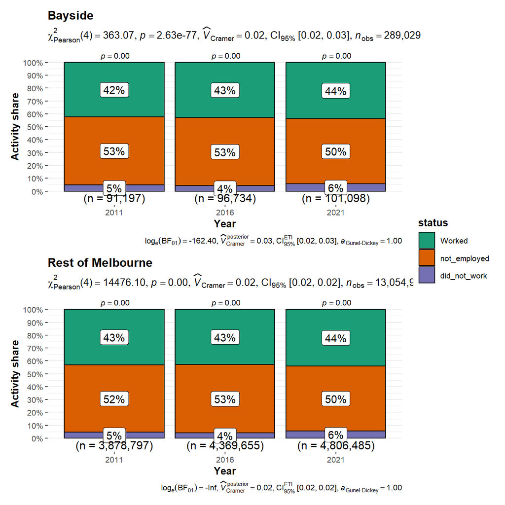

Around 44k people resident in Bayside worked on census day in 2021, up from around 39k in 2011 . The share of the population working increased from 42.1% to 43.8%, as did the share of the population who were employed but did not work on the day of the census itself (from 4.9% to 5.8%). Changes in the share of the population working, not working and not employed in Bayside are generally similar to those for the rest of Melbourne.

Journey-to-work mode and WFH status on census day

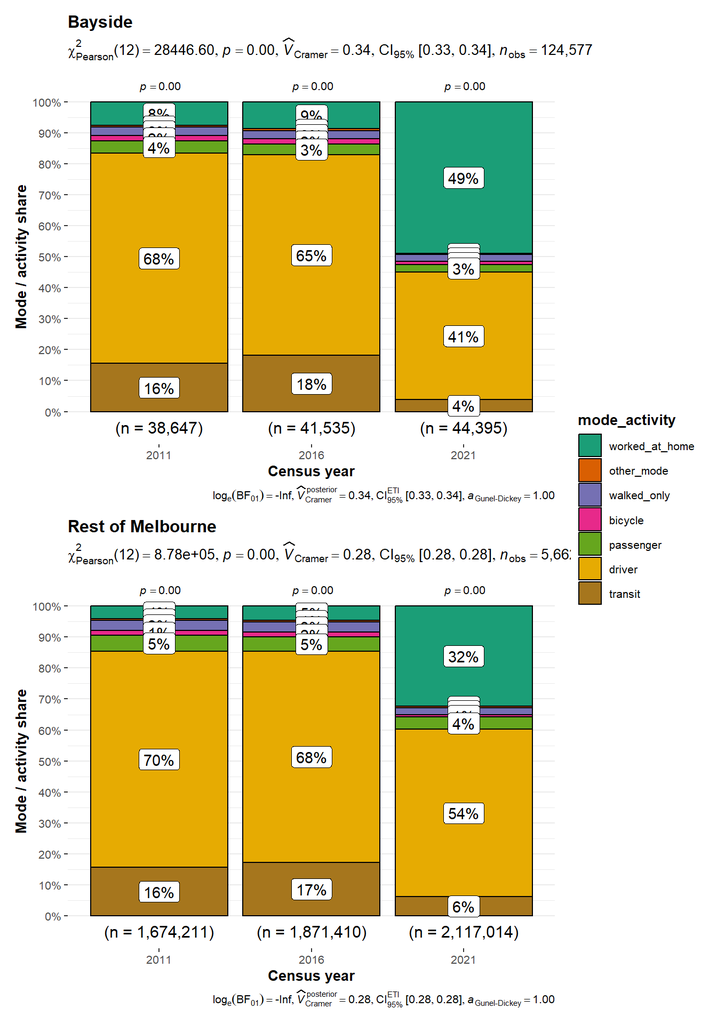

Journey-to-work mode and WFH status on census day

| Year | Location | Public Transport | Private vehicle (driver) | Private vehicle (passenger) | Bicycle | Walked only | Other mode | Worked at home | Total |
| --- | --- | --- | --- | --- | --- | --- | --- | --- | --- |
| 2011 | Bayside | 15.5% (5,995) | 68.0% (26,265) | 3.9% (1,497) | 1.8% (713) | 2.7% (1,031) | 0.5% (181) | 7.7% (2,965) | 100.0% (38,647) |
| 2011 | Rest of Melbourne | 15.6% (261,603) | 69.8% (1,168,501) | 5.2% (87,734) | 1.5% (25,022) | 3.3% (55,383) | 0.5% (8,139) | 4.1% (67,829) | 100.0% (1,674,211) |
| 2016 | Bayside | 18.2% (7,546) | 64.8% (26,909) | 3.5% (1,439) | 1.7% (707) | 2.5% (1,046) | 0.7% (274) | 8.7% (3,614) | 100.0% (41,535) |
| 2016 | Rest of Melbourne | 17.3% (323,256) | 68.2% (1,275,702) | 4.6% (85,969) | 1.6% (29,056) | 3.3% (62,169) | 0.5% (10,180) | 4.5% (85,078) | 100.0% (1,871,410) |
| 2021 | Bayside | 3.8% (1,701) | 41.2% (18,284) | 2.5% (1,114) | 0.9% (402) | 2.3% (1,007) | 0.4% (178) | 48.9% (21,709) | 100.0% (44,395) |
| 2021 | Rest of Melbourne | 6.1% (129,977) | 54.0% (1,144,098) | 4.0% (83,932) | 0.8% (17,789) | 2.2% (47,319) | 0.5% (10,279) | 32.3% (683,620) | 100.0% (2,117,014) |

Pre-COVID, Bayside’s journey-to-work transit mode share was up more (15.5% in 2011 to 18.2% in 2016) than rest of Melbourne (15.6% to 17.3%). In 2021, Bayside has a lower transit (3.8%) and higher WFH share (48.9%) than the rest of Melbourne (6.1% and 32.3%).

During COVID there were large shifts to WFH in both Bayside (49%) and the rest of Melbourne (32%). Transit use dropped to 4% and 6%, while driving also dropped to 41% and 54% respectively.

Journey-to-work mode and WFH status on census day

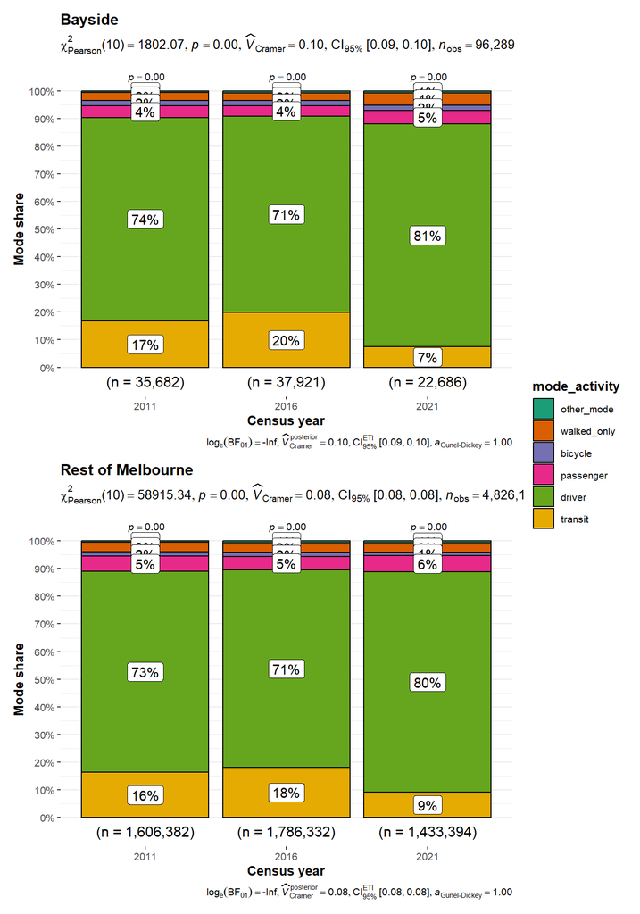

Amongst those still traveling to work there was a shift from transit to driving. The drop in transit share was larger in Bayside (20% to 7%) than for the rest of Melbourne (18% to 9%)

Transit mode share on census day

| Year | Location | Train | Bus | Tram | Ferry | Total |
| --- | --- | --- | --- | --- | --- | --- |
| 2011 | Bayside | 91.7% (5,495) | 5.1% (308) | 3.1% (184) | 0.1% (8) | 100.0% (5,995) |
| 2011 | Rest of Melbourne | 71.2% (186,259) | 11.0% (28,869) | 17.6% (45,990) | 0.2% (485) | 100.0% (261,603) |
| 2016 | Bayside | 93.4% (7,048) | 4.3% (325) | 2.2% (168) | 0.1% (5) | 100.0% (7,546) |
| 2016 | Rest of Melbourne | 73.0% (235,924) | 9.8% (31,576) | 17.0% (54,991) | 0.2% (765) | 100.0% (323,256) |
| 2021 | Bayside | 85.4% (1,453) | 10.7% (182) | 3.4% (58) | 0.5% (8) | 100.0% (1,701) |
| 2021 | Rest of Melbourne | 66.4% (86,342) | 15.5% (20,164) | 17.5% (22,733) | 0.6% (738) | 100.0% (129,977) |

Transit mode share on census day

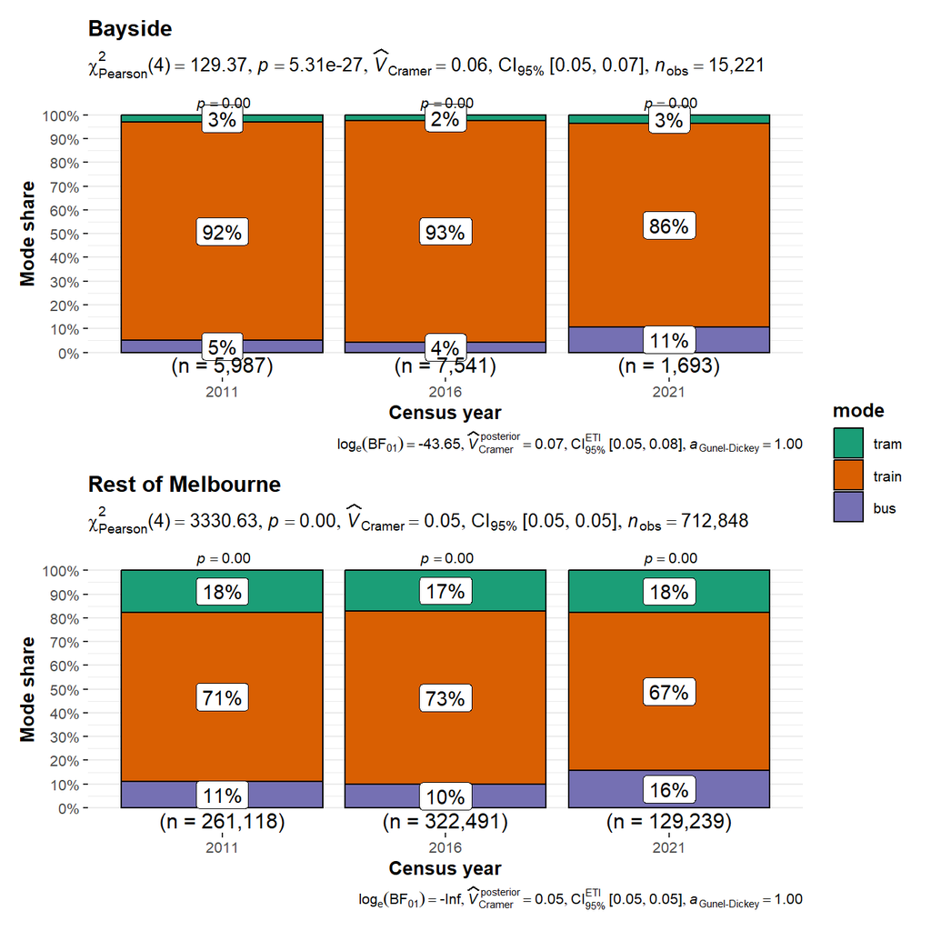

For transit users, there has been a shift in mode share from train to bus between 2016 and 2021. However, train still dominates in both Bayside (86%) and the rest of Melbourne (67%).

# Discussion and Conclusions

Findings from this review of census data for 2011, 2016 and 2021 for the City of Bayside and the rest of Greater Melbourne include:

## Population:

- The City of Bayside makes up around 2% of the population of Greater Melbourne.
- There were around 10,000 more people living in Bayside in 2021 compared to 2011 (+10%).
- This growth rate is less than that of Greater Melbourne as a whole (+23%).
- Around 79K people in Bayside in 2021 were aged 18 years or older (78.3%). This is a similar share to the rest of Greater Melbourne (78.5%).

Parked at or near dwellings on census night. Not including trucks or bicycles.

## Working status:

- ~44k Bayside residents worked on census day in 2021 (43.8%), ~6k were employed by not working (5.8%) and ~51k (50.2%) were not in the labor force. This share is generally similar to the rest of Greater Melbourne.

  A small number were eligible to, but did not respond to the JTW question (196, 0.2%), and so are not included in the other categories.
- There were around 6k more people living in Bayside who worked on census day in 2021 than in 2011 (+15%), but this rate of increase is less than the rest of Greater Melbourne (+26%)

## Journey-to-work and WFH mode/activity share:

- Transit use had increasing pre-COVID in Bayside, from 15% in 2011 to 18.2% in 2016.
- This increase was higher than for the rest of Greater Melbourne (15.6% to 17.3%)
- Driving a private vehicle had dropped in Bayside from 68% in 2011 to 64.8% in 2016, both of which were lower than the rest of Greater Melbourne (69.8% dropping to 68.2%).
- COVID-19 induced a large shift from transit (3.8% in Bayside in 2021) and driving (41.2%) to WFH (up from 8.7% in 2016 to 48.9% in 2021).
- The shift to WFH was more pronounced in Bayside than the rest of Greater Melbourne, which was 6.1% transit, 54% drive and 32.3% WFH in 2021.
- For those travelling to work, there was a shift from transit to driving. In Bayside transit share dropped from 20% in 2016 to 7% in 2021, while driving increased from 71% to 81%. These changes were similar to the rest of Greater Melbourne.

  Transit 18% in 2016 to 9% in 2021. Driving 71% in 2016 to 80% in 2021.
- Among transit users there was a shift from train to bus.

  Bayside 93% in 2016 to 86% in 2021, rest of Melbourne 73% to 67%

  4% to 11% for Bayside, and 10% to 16% for the rest of Greater Melbourne

## Overall

- Bayside has been growing in people and vehicles, but at lower rates than the rest of Greater Melbourne.
- Transit mode share was going up, but COVID led to a very large shift to WFH, which is larger in Bayside than the rest of Greater Melbourne.
- Transit (especially train) has lost share to driving, but the number of people driving to work has still decreased by around 9k while transit JTW ridership has fallen only around 6k.

  Down 32% from ~27k to ~18k in Bayside, compared to a fall of 10% for the rest of Greater Melbourne

  Down 78% from ~8k to ~2k, compared to a fall of 60% for the rest of Greater Melbourne

Overall, in comparison to the rest of Greater Melbourne, Bayside had: lower growth in population and vehicles; greater drops in JTW transit ridership and driving; but more vehicles per person aged 18 or older and more WFH.